# naive bayes penguins

### Libraries

```r
library(tidyverse)
library(bayesrules)
library(janitor)
library(e1071)
options(scipen = 99)
```

### Story

We’ll start our naive Bayes classification with just a single penguin. Suppose an Antarctic researcher comes across a penguin that weighs less than 4200g with a 195mm-long flipper and 50mm-long bill. Our goal is to help this researcher identify the species of this penguin, Adelie, Chinstrap, or Gentoo.

#### Let’s Plot!

Make a visualization that will help the researcher determine the species based on the characteristics described above

```r
data(penguins_bayes)
penguins <- penguins_bayes
```

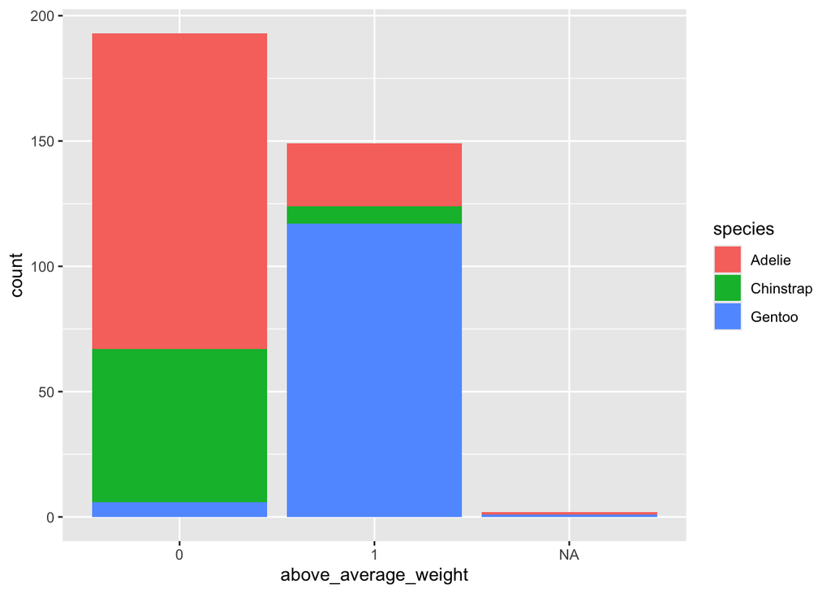

```r
ggplot(data = penguins, aes(x = above_average_weight, fill = species)) +
  geom_bar()
```

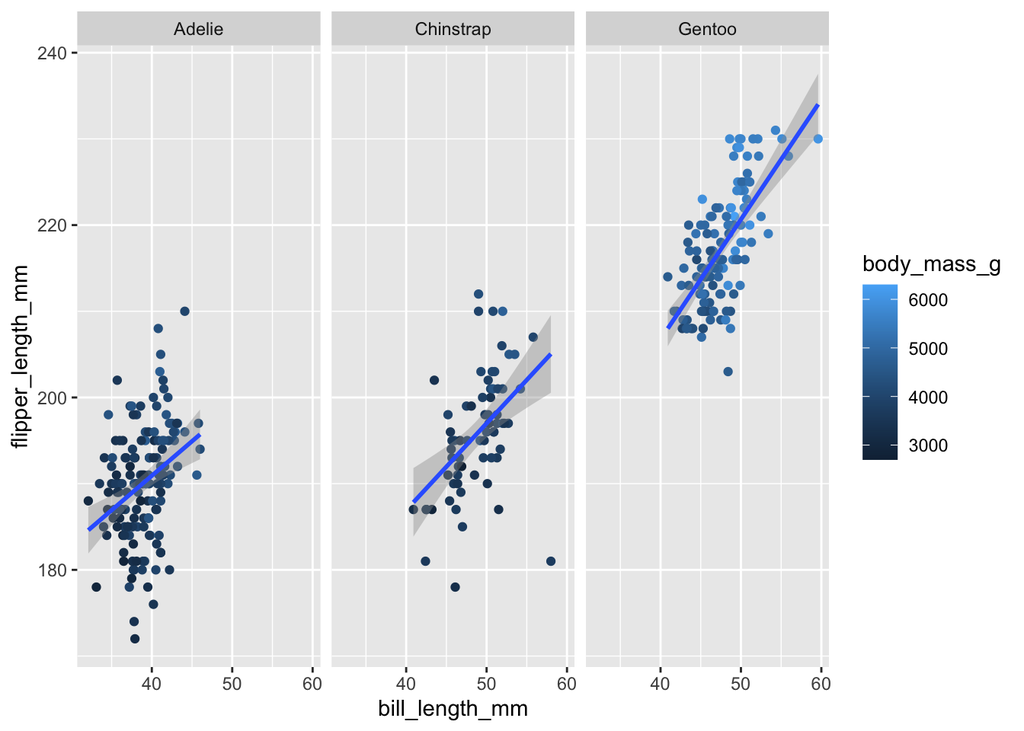

```r
ggplot(data = penguins, aes(bill_length_mm, flipper_length_mm, color = body_mass_g)) +
  geom_point() +
  geom_smooth(method = "lm") +
  facet_grid(~species)
```

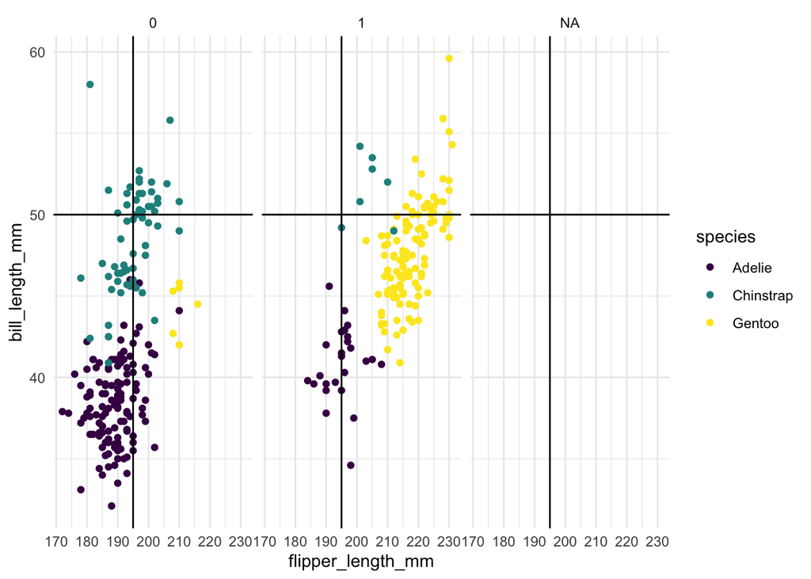

```r
ggplot(penguins, aes(x = flipper_length_mm, y = bill_length_mm, color = species)) +
  geom_point() +
  facet_wrap(~ above_average_weight) +
  theme_minimal() +
  scale_color_viridis_d() +
  geom_hline(yintercept = 50) +
  geom_vline(xintercept = 195)
```

Replace 1 with yes and 0 with no

```r
penguins <- penguins %>%
  mutate(above_average_weight = if_else(above_average_weight == 1, "yes", "no"))
```

Our old bayesian ways

P(B|A)

- P(Chinstrap | below average weight)

```r
penguins %>%
  tabyl(above_average_weight, species) %>%
  adorn_percentages("row")
```

```
##  above_average_weight    Adelie  Chinstrap     Gentoo
##                    no 0.6528497 0.31606218 0.03108808
##                   yes 0.1677852 0.04697987 0.78523490
##                  <NA> 0.5000000 0.00000000 0.50000000
```

#### Naive Bayes Classification!

```r
naive_model_hints <- naiveBayes(species ~ flipper_length_mm + bill_length_mm + above_average_weight, data = penguins)
```

Our penguin

```r
our_penguin <- data.frame(bill_length_mm = 50, flipper_length_mm = 195, above_average_weight = "no")
```

Ask our model to make a prediction of what species our penguin is

```r
predict(naive_model_hints, newdata = our_penguin, type = "raw")
```

```
##            Adelie Chinstrap       Gentoo
## [1,] 0.0003219805 0.9994165 0.0002615187
```

Test our model fro accuracy with confusion matrix

```r
penguins <- penguins %>%
  mutate(predicted_species = predict(naive_model_hints, newdata = .))
```

```r
penguins %>%
  tabyl(species, predicted_species) %>%
  adorn_percentages("row") %>%
  adorn_pct_formatting(digits = 2) %>%
  adorn_ns
```

```
##    species       Adelie   Chinstrap       Gentoo
##     Adelie 96.05% (146)  2.63%  (4)  1.32%   (2)
##  Chinstrap  7.35%   (5) 86.76% (59)  5.88%   (4)
##     Gentoo  0.81%   (1)  4.03%  (5) 95.16% (118)
```

```r
naive_model_hints
```

```
##
## Naive Bayes Classifier for Discrete Predictors
##
## Call:
## naiveBayes.default(x = X, y = Y, laplace = laplace)
##
## A-priori probabilities:
## Y
##    Adelie Chinstrap    Gentoo
## 0.4418605 0.1976744 0.3604651
##
## Conditional probabilities:
##            flipper_length_mm
## Y               [,1]     [,2]
##   Adelie    189.9536 6.539457
##   Chinstrap 195.8235 7.131894
##   Gentoo    217.1870 6.484976
##
##            bill_length_mm
## Y               [,1]     [,2]
##   Adelie    38.79139 2.663405
##   Chinstrap 48.83382 3.339256
##   Gentoo    47.50488 3.081857
##
##            above_average_weight
## Y                   no        yes
##   Adelie    0.83443709 0.16556291
##   Chinstrap 0.89705882 0.10294118
##   Gentoo    0.04878049 0.95121951
```

## Lecture 2 - Under the hood of Naive Bayes

### Adelie

#### Species

```r
penguins %>%
  tabyl(species)
```

```
##    species   n   percent
##     Adelie 152 0.4418605
##  Chinstrap  68 0.1976744
##     Gentoo 124 0.3604651
```

#### Flipper Length - Probability density function

- first argument = our penguins flipper length
- second argument = mean flipper length for adelie penguins
- third argument = standard deviation in flipper length for adelie penguins

```r
dnorm(195, mean = 190, sd = 6.54)
```

```
## [1] 0.04554175
```

What happened here

- a picture worth a thousand words

[figure not shown]

```r
# Filter penguins dataset for Adelie species
adelie_penguins <- subset(penguins, species == "Adelie")

# Calculate mean and standard deviation of flipper_length_mm for Adelie penguins
mean_flipper <- mean(adelie_penguins$flipper_length_mm, na.rm = TRUE)
sd_flipper <- sd(adelie_penguins$flipper_length_mm, na.rm = TRUE)

# Value to highlight (195 mm)
highlight_value <- 195
highlight_density <- dnorm(highlight_value, mean = mean_flipper, sd = sd_flipper)

# Plot the normal distribution with a point for 195 mm and 1 standard deviation lines
ggplot(adelie_penguins, aes(x = flipper_length_mm)) +
  geom_density(color = "blue", size = 1) +  # Plot the density curve

  # Highlight the point for 195 mm
  geom_point(aes(x = highlight_value, y = highlight_density),
             color = "red", size = 3) +

  # Add a vertical dashed line for 195 mm
  geom_vline(xintercept = highlight_value, linetype = "dashed", color = "red") +

  # Add vertical lines for 1 standard deviation from the mean
  geom_vline(xintercept = mean_flipper + sd_flipper, linetype = "dotted", color = "black") +
  geom_vline(xintercept = mean_flipper - sd_flipper, linetype = "dotted", color = "black") +

  # Add annotations for standard deviation lines
  annotate("text", x = mean_flipper + sd_flipper + 1, y = 0.01,
           label = "+1 SD", color = "black", hjust = 0) +
  annotate("text", x = mean_flipper - sd_flipper - 1, y = 0.01,
           label = "-1 SD", color = "black", hjust = 1) +

  # Add labels and title
  labs(title = "Normal Distribution of Flipper Lengths for Adelie Penguins",
       subtitle = paste("Mean =", round(mean_flipper, 2), "mm, SD =", round(sd_flipper, 2), "mm"),
       x = "Flipper Length (mm)", y = "Density") +

  # Add annotation for 195 mm
  annotate("text", x = highlight_value + 2, y = highlight_density,
           label = paste0("195 mm\nDensity: ", round(highlight_density, 5)),
           hjust = 0, color = "red") +

  # Minimal theme for cleaner look
  theme_minimal()
```

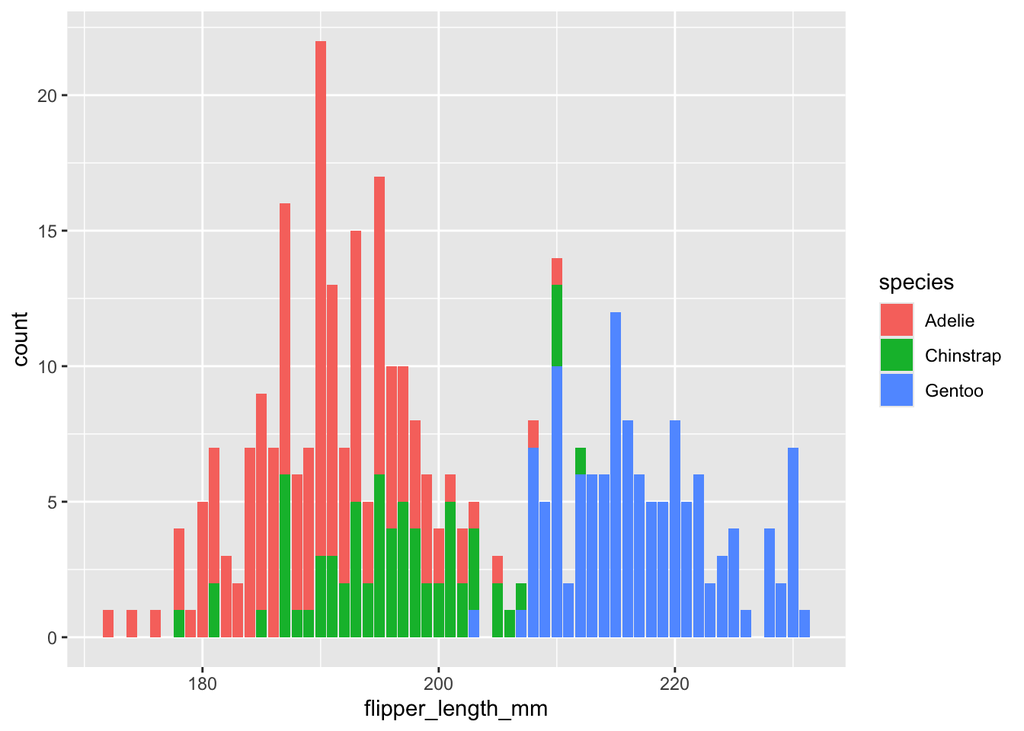

```r
ggplot(data = penguins, aes(x = flipper_length_mm, fill = species)) +
  geom_bar()
```

#### Bill Length

```r
dnorm(50, mean = 38.79139, sd = 2.663405)
```

```
## [1] 0.00002136495
```

#### Above Average Weight

```r
penguins %>%
  tabyl(species, above_average_weight) %>%
  adorn_percentages("row")
```

```
##    species        no       yes         NA_
##     Adelie 0.8289474 0.1644737 0.006578947
##  Chinstrap 0.8970588 0.1029412 0.000000000
##     Gentoo 0.0483871 0.9435484 0.008064516
```

P(Adelie) * P(Adelie | 195 mm flipper) * P(Adelie | 50 mm bill) * P(under average weight | Adelie)

^ from the dnorm function and the model

```r
probs_adelie <- (152/342) * 0.04554 * 0.0000212  * 0.83
probs_adelie
```

```
## [1] 0.000000356143
```

### Chinstrap

#### Species

```r
penguins %>%
  tabyl(species)
```

```
##    species   n   percent
##     Adelie 152 0.4418605
##  Chinstrap  68 0.1976744
##     Gentoo 124 0.3604651
```

#### Flipper Length

```r
dnorm(195, mean = 195.8235, sd = 7.131894)
```

```
## [1] 0.05556611
```

#### Bill Length

```r
dnorm(50, mean = 48.83382, sd = 3.339256)
```

```
## [1] 0.1124026
```

#### Above Average Weight

```r
penguins %>%
  tabyl(species, above_average_weight) %>%
  adorn_percentages("row")
```

```
##    species        no       yes         NA_
##     Adelie 0.8289474 0.1644737 0.006578947
##  Chinstrap 0.8970588 0.1029412 0.000000000
##     Gentoo 0.0483871 0.9435484 0.008064516
```

P(Chinstrap) * P(Chinstrap | 195 mm flipper) * P(Chinstrap | 50 mm bill) * P(under average weight | Chinstrap)

```r
probs_chinstrap <- (68/342) * 0.05541 * 0.112 * 0.89
probs_chinstrap
```

```
## [1] 0.001098194
```

### Find Gentoo

#### Flipper Length

Gentoo -

```
 217.1870 6.484976
```

```r
dnorm(195, mean = 217.1870, sd = 6.484976)
```

```
## [1] 0.0001767016
```

#### Bill Length

Gentoo -

```
47.50488 3.081857
```

```r
dnorm(50, mean = 47.50488, sd = 3.081857)
```

```
## [1] 0.09327439
```

#### Above Average Weight

```r
penguins %>%
  tabyl(species, above_average_weight) %>%
  adorn_percentages("row")
```

```
##    species        no       yes         NA_
##     Adelie 0.8289474 0.1644737 0.006578947
##  Chinstrap 0.8970588 0.1029412 0.000000000
##     Gentoo 0.0483871 0.9435484 0.008064516
```

```r
probs_gentoo <- (124/342) * 0.0001767016 * 0.09327439 * 0.0483871
probs_gentoo
```

```
## [1] 0.0000002891532
```

### Sum of Probabilities

```r
sum_of_probs <- probs_adelie + probs_chinstrap + probs_gentoo
sum_of_probs
```

```
## [1] 0.001098839
```

#### Probability Chinstrap

```r
probs_chinstrap / sum_of_probs
```

```
## [1] 0.9994127
```